# Data analysis of mollusks and echinoderms abundance

## 7.5 Evaluate the nMDS mapping based on the stress and goodness of fit

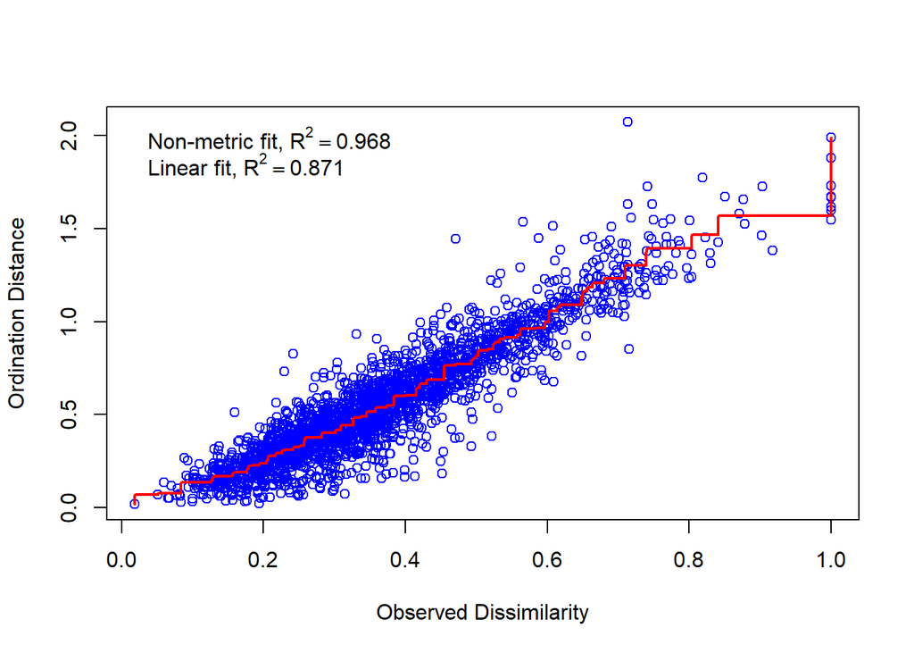

```r
stressplot(inv_nmds_br) #evaluating NMDS mapping: stressplot
```

```r
inv_nmds_br_gof=goodness(inv_nmds_br) #evaluating NMDS mapping: goodness of fit
inv_nmds_br_gof #smaller the value, the lower stress and better fit
```

```
##  [1] 0.02528647 0.03142630 0.01433772 0.01530589 0.02572981 0.02131288
##  [7] 0.03529237 0.02180785 0.03732432 0.02010680 0.01978958 0.02043524
## [13] 0.02805966 0.02290582 0.03453777 0.02277867 0.01673624 0.02253467
## [19] 0.02044035 0.03149735 0.02775252 0.01344634 0.01449326 0.02054750
## [25] 0.02847461 0.01996928 0.02063970 0.01443655 0.02020365 0.01341818
## [31] 0.01654242 0.02289272 0.01441876 0.01364178 0.01867879 0.01480400
## [37] 0.03062894 0.02668912 0.01370139 0.02045545 0.01540751 0.01818515
## [43] 0.01937016 0.01491937 0.01290959 0.02152415 0.01927020 0.01894342
## [49] 0.01568448 0.01607715 0.02103473 0.01304252 0.01912931 0.01755167
## [55] 0.01608824 0.02156345 0.01999863 0.01285089 0.01330107 0.02601833
## [61] 0.02087086 0.01641873 0.01728469 0.02052769 0.01521375 0.01308075
## [67] 0.02650265 0.03582518 0.03538992
```

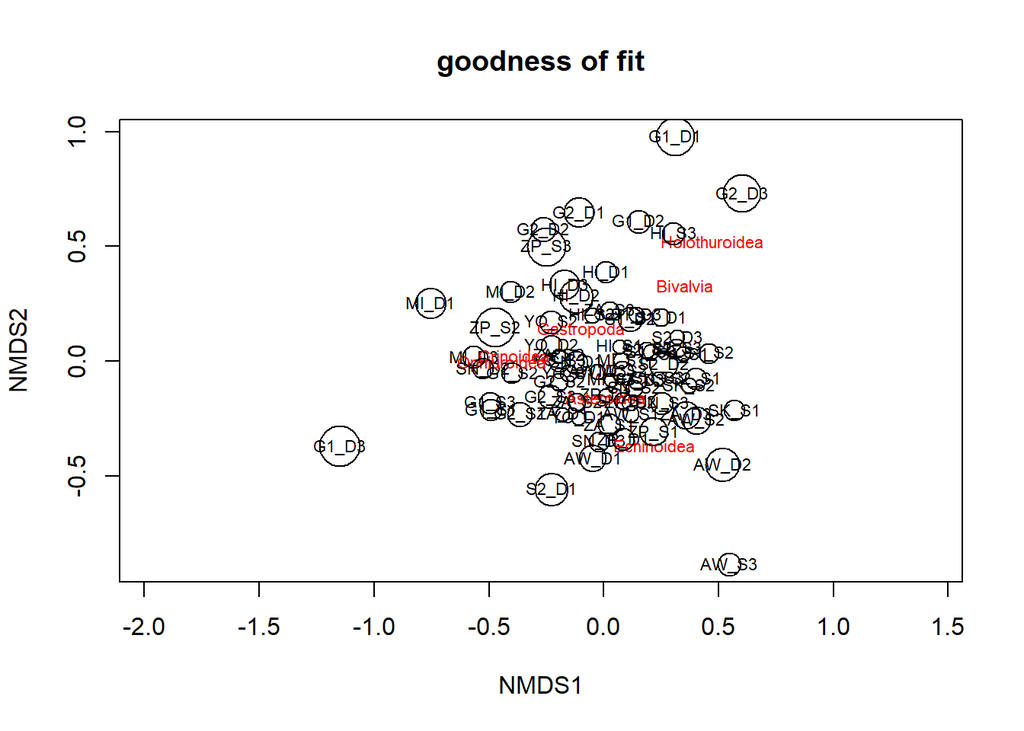

```r
plot(inv_nmds_br, type="t", main="goodness of fit") # create a plot for goodness of fit visualization:
points(inv_nmds_br, display="site", cex=inv_nmds_br_gof*100) #display the goodness of fit on the plot
```

```r
#Stress lesser, better (>0.2 poor,0.2-0.1 moderate,0.1-0.05 good,<0.05 excellent);
#K level higher, stress lesser
str(inv_nmds_br)
```

```
## List of 36
##  $ nobj      : int 69
##  $ nfix      : int 0
##  $ ndim      : num 2
##  $ ndis      : int 2346
##  $ ngrp      : int 1
##  $ diss      : num [1:2346] 0.0184 0.0515 0.0592 0.0653 0.0674 ...
##  $ iidx      : int [1:2346] 41 58 45 65 59 59 57 50 50 28 ...
##  $ jidx      : int [1:2346] 36 52 44 4 53 17 55 30 49 22 ...
##  $ xinit     : num [1:138] 0.139 0.563 0.299 0.824 0.613 ...
##  $ istart    : int 1
##  $ isform    : int 1
##  $ ities     : int 1
##  $ iregn     : int 1
##  $ iscal     : int 1
##  $ maxits    : int 200
##  $ sratmx    : num 1
##  $ strmin    : num 1e-04
##  $ sfgrmn    : num 1e-07
##  $ dist      : num [1:2346] 0.019 0.0701 0.1372 0.0517 0.0514 ...
##  $ dhat      : num [1:2346] 0.019 0.0701 0.0771 0.0771 0.0771 ...
##  $ points    : num [1:69, 1:2] -0.0476 0.5176 -0.0281 0.1175 0.4038 ...
##   ..- attr(*, "dimnames")=List of 2
##   .. ..$ : chr [1:69] "AW_D1" "AW_D2" "AW_D3" "AW_S1" ...
##   .. ..$ : chr [1:2] "MDS1" "MDS2"
##   ..- attr(*, "centre")= logi TRUE
##   ..- attr(*, "pc")= logi TRUE
##   ..- attr(*, "halfchange")= logi TRUE
##   ..- attr(*, "internalscaling")= num 2.22
##  $ stress    : num 0.18
##  $ grstress  : num 0.18
##  $ iters     : int 122
##  $ icause    : int 3
##  $ call      : language metaMDS(comm = inv_mat, distance = "bray", k = 2)
##  $ model     : chr "global"
##  $ distmethod: chr "bray"
##  $ distcall  : chr "vegdist(x = comm, method = distance)"
##  $ data      : chr "inv_mat"
##  $ distance  : chr "bray"
##  $ converged : num 5
##  $ tries     : num 20
##  $ bestry    : num 3
##  $ engine    : chr "monoMDS"
##  $ species   : num [1:7, 1:2] 0.35352 -0.09598 0.00832 -0.38878 0.22246 ...
##   ..- attr(*, "dimnames")=List of 2
##   .. ..$ : chr [1:7] "Bivalvia" "Gastropoda" "Asteroidea" "Crinoidea" ...
##   .. ..$ : chr [1:2] "MDS1" "MDS2"
##   ..- attr(*, "shrinkage")= Named num [1:2] 0.1012 0.0963
##   .. ..- attr(*, "names")= chr [1:2] "MDS1" "MDS2"
##   ..- attr(*, "centre")= Named num [1:2] 0.0378 -0.0188
##   .. ..- attr(*, "names")= chr [1:2] "MDS1" "MDS2"
##  - attr(*, "class")= chr [1:2] "metaMDS" "monoMDS"
```

Stress = 0.1796949 < 0.2

Check Stress for each additional dimension

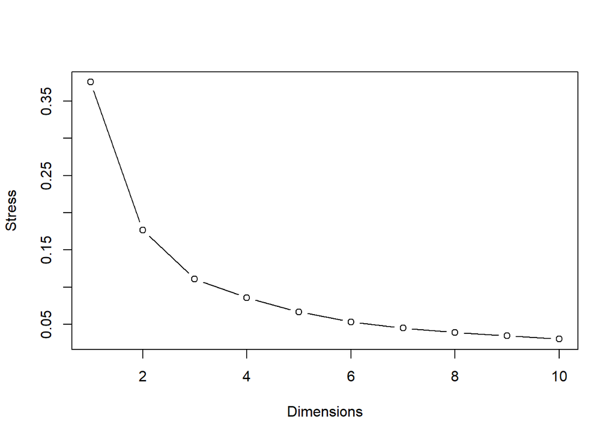

```r
k_vec=1:10
stress=numeric(length(k_vec))
inv_dij=metaMDSdist(inv_mat, trace=FALSE)
set.seed(69)
for(i in seq_along(k_vec)) {
  inv_nmds_br_loop=metaMDSiter(inv_dij, k=i, trace=FALSE)
  stress[i]=inv_nmds_br_loop$stress
}
plot(k_vec,stress,type="b",ylab="Stress",xlab="Dimensions") #select the K correspondent to the most drastic drop in stress
```

## 7.6 nMDS visualization of nMDS plot with `ggplot()`

N.B. Visualisation with ggplot()` first require the creation of an input dataframe with nMDS scores

```r
inv_ndms_scores <- as.data.frame(scores(inv_nmds_br)$sites)  #Using the scores function from vegan to extract the site scores and convert to a data.frame
inv_ndms_scores$transect <- rownames(inv_ndms_scores) # create a column of transect names
inv_ndms_scores$site <- ind_df$site
inv_ndms_scores$depth <- ind_df$depth  #  add the grp variable created earlier
str(inv_ndms_scores)  #look at the data
```

```
## 'data.frame':    69 obs. of  5 variables:
##  $ NMDS1   : num  -0.0476 0.5176 -0.0281 0.1175 0.4038 ...
##  $ NMDS2   : num  -0.4257 -0.4513 -0.0448 -0.2335 -0.2576 ...
##  $ transect: chr  "AW_D1" "AW_D2" "AW_D3" "AW_S1" ...
##  $ site    : Ord.factor w/ 12 levels "HI"<"S1"<"S2"<..: 10 10 10 10 10 10 11 11 11 11 ...
##  $ depth   : Factor w/ 2 levels "D","S": 1 1 1 2 2 2 1 1 1 2 ...
```

```r
NMDS1 <- inv_nmds_br$points[,1] ##also found using: > scores(faMDS)
NMDS2 <- inv_nmds_br$points[,2]
nmds_df<-cbind(ind_df, NMDS1, NMDS2)
```

nMDS plot with `ggplot()` with stress value

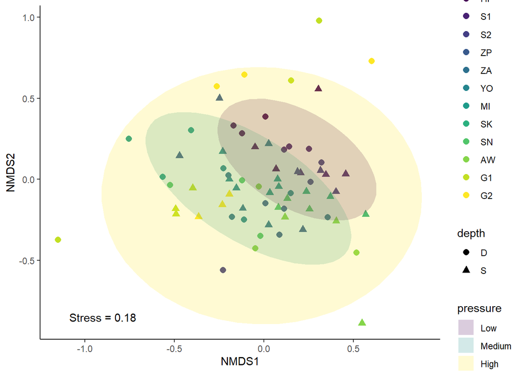

```r
inv_ndms_ggplot<-ggplot(nmds_df, aes(NMDS1, NMDS2))+
  geom_point(data=nmds_df, aes(NMDS1, NMDS2, color=site, shape=depth),size=2.5)+##separates overlapping points
  stat_ellipse(geom="polygon",
               aes(fill=pressure), alpha=.2,type='t',size =1)+ ##draws 95% confidence interval ellipses
  theme_classic()+
  annotate("text", x=-0.9, y=-0.85,
           label=paste('Stress =',round(inv_nmds_br$stress,3))) #add stress to plot
inv_ndms_ggplot
```

## 7.7 nMDS plot with `geom_mark_ellipse()` from `ggforce`

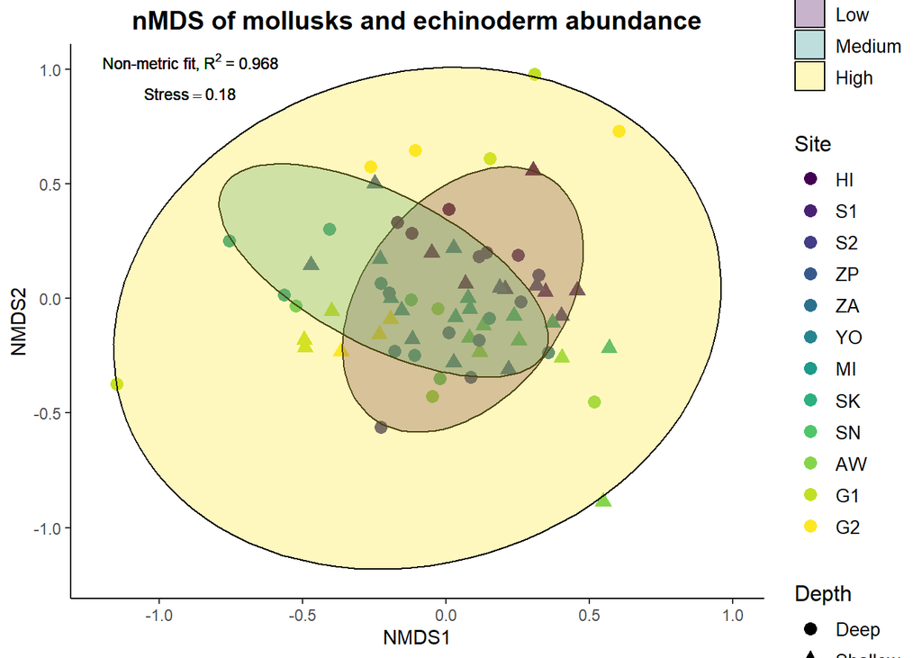

```r
#install.packages("ggforce")
library(ggforce)

inv_ndms_ggplot <- ggplot(nmds_df, aes(NMDS1, NMDS2))+
  geom_point(data=nmds_df, aes(NMDS1, NMDS2, color=site, shape=depth),size=3)+##separates overlapping points
  geom_mark_ellipse(aes(fill=pressure), expand = 0)+ # https://luisdva.github.io/rstats/Grouping-points/
  theme_classic()+
  ggtitle("nMDS of mollusks and echinoderm abundance")+
  theme(legend.position = "right",
        plot.title = element_text(size=14, face="bold",hjust=.5),
        legend.title = element_text(color = "black", size = 12),
        legend.text = element_text(size=10))+
  guides(color = guide_legend(order = 1,title="Site"),
         fill = guide_legend(order = 1,title="Pressure"),
         shape = guide_legend(order = 2,title="Depth",))+
  scale_shape_manual(labels = c("Deep", "Shallow"),values = c(16,17))+
  scale_x_continuous(limits = c(-1.2,1))+
  scale_y_continuous(limits = c(-1.2,1))+
  annotate("text", x=-1.20, y=0.97,
           label=bquote(atop('Non-metric fit,'~ R^2~"= 0.968",
                             Stress == .(round(inv_nmds_br$stress,3)),
                             )),
           size=3, hjust=0)

inv_ndms_ggplot
```

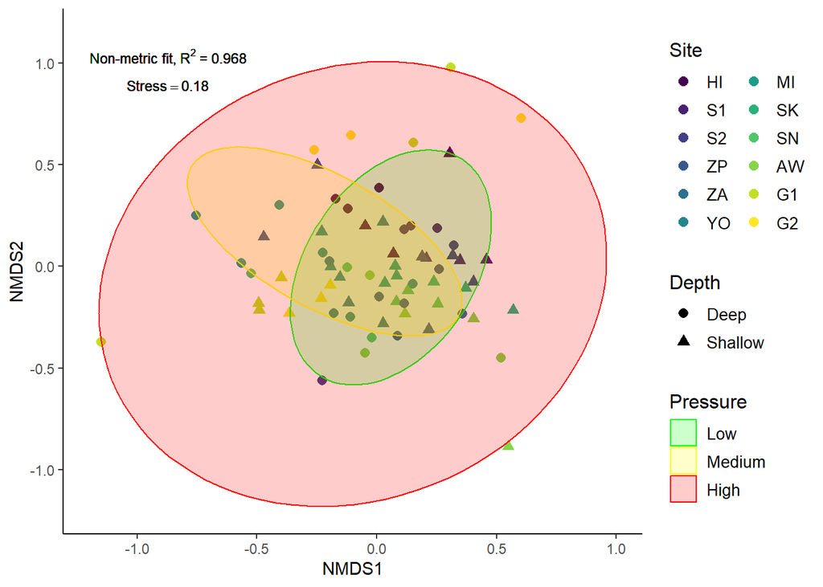

```r
pal12 <- c("#000000","#004949","#009292","#ffb6db",
 "#490092","#006ddb","#b66dff","#b6dbff",
 "#920000","#924900","#24ff24","#ffff6d")

ggplot(nmds_df, aes(NMDS1, NMDS2))+
  geom_point(data=nmds_df, aes(NMDS1, NMDS2, color=site, shape=depth),
             size=2.5)+##separates overlapping points
  guides(color = guide_legend(order=1, title = "Site", ncol =2),
         shape = guide_legend(order=2, title = "Depth"))+
  scale_shape_manual(labels = c("Deep", "Shallow"),values = c(16,17))+
  ggnewscale::new_scale_color() +
  geom_mark_ellipse(aes(fill=pressure, color=pressure), expand = 0, alpha=0.2)+ # https://luisdva.github.io/rstats/Grouping-points/
  scale_color_manual(values= c("green","yellow","red"),
                      aesthetics = c("colour", "fill"),
                     guide = guide_legend(title = "Pressure"))+
  theme_classic()+
  theme(plot.title = element_text(size=14, face="bold",hjust=.5),
        legend.title = element_text(color = "black", size = 12),
        legend.text = element_text(size=10))+
  scale_x_continuous(limits = c(-1.2,1))+
  scale_y_continuous(limits = c(-1.2,1.15))+
  annotate("text", x=-1.20, y=0.97,
           label=bquote(atop('Non-metric fit,'~ R^2~"= 0.968",
                             Stress == .(round(inv_nmds_br$stress,3)),
                             )),
           size=3, hjust=0) #add goodness of fit to plot
```

```r
ggsave("inv_ndms_ggplot.tiff",
       units="in", width=7, height=5, dpi=300, compression = 'lzw',
       path = here ("Multi-taxa_data","MollEchino","Output"))
```

# 8 PERMANOVA AND POST-HOC PAIRWISE PERMANOVA

Load libraries

```r
#VEGAN----
library(vegan)#load package
library(MASS)
library(dplyr)

#install.packages("pairwiseAdonis")
library(devtools) #to install pairwiseAdonis from GitHub
library(pairwiseAdonis)
#install.packages("Rtools")
# library(remotes) #to use install_github
# install_github("pmartinezarbizu/pairwiseAdonis/pairwiseAdonis")
library(pairwiseAdonis)
```

Display input matrix and data frame with independent variables

```r
str(inv_mat)
```

```
##  num [1:69, 1:7] 0 0.693 1.609 1.386 2.639 ...
##  - attr(*, "dimnames")=List of 2
##   ..$ : chr [1:69] "AW_D1" "AW_D2" "AW_D3" "AW_S1" ...
##   ..$ : chr [1:7] "Bivalvia" "Gastropoda" "Asteroidea" "Crinoidea" ...
```

```r
head(inv_mat)
```

```
##        Bivalvia Gastropoda Asteroidea Crinoidea Echinoidea Holothuroidea
## AW_D1 0.0000000  1.0986123  1.3862944  1.945910   3.713572      1.098612
## AW_D2 0.6931472  0.6931472  0.6931472  0.000000   4.043051      1.098612
## AW_D3 1.6094379  1.7917595  0.6931472  2.397895   3.332205      0.000000
## AW_S1 1.3862944  1.7917595  0.6931472  2.079442   5.739793      0.000000
## AW_S2 2.6390573  0.0000000  0.6931472  2.564949   5.707110      1.098612
## AW_S3 0.0000000  0.0000000  0.0000000  0.000000   5.575949      0.000000
##       Ophiuroidea
## AW_D1           0
## AW_D2           0
## AW_D3           0
## AW_S1           0
## AW_S2           0
## AW_S3           0
```

```r
str(ind_df)
```

```
## 'data.frame':    69 obs. of  5 variables:
##  $ transect  : chr  "AW_D1" "AW_D2" "AW_D3" "AW_S1" ...
##  $ site      : Ord.factor w/ 12 levels "HI"<"S1"<"S2"<..: 10 10 10 10 10 10 11 11 11 11 ...
##  $ depth     : Factor w/ 2 levels "D","S": 1 1 1 2 2 2 1 1 1 2 ...
##  $ site_depth: Factor w/ 23 levels "AW_D","AW_S",..: 1 1 1 2 2 2 3 3 3 4 ...
##  $ pressure  : Ord.factor w/ 3 levels "Low"<"Medium"<..: 3 3 3 3 3 3 3 3 3 3 ...
```

## 8.1 PERMANOVA among the 12 sites

```r
#ALTERNATIVE SCRIPT WITH adonis2()
set.seed(69)
h <- how(nperm = 9999)
inv_permanova <- adonis2(inv_mat ~ pressure/site*depth,
                             data=ind_df,
                             permutations =h,
                             methods="bray")

inv_permanova
```

```
## Permutation test for adonis under reduced model
## Terms added sequentially (first to last)
## Permutation: free
## Number of permutations: 9999
##
## adonis2(formula = inv_mat ~ pressure/site * depth, data = ind_df, permutations = h, methods = "bray")
##                     Df SumOfSqs      R2      F Pr(>F)
## pressure             2   0.5991 0.11213 7.3996  1e-04 ***
## depth                1   0.3094 0.05791 7.6436  1e-04 ***
## pressure:site        9   1.2731 0.23828 3.4943  1e-04 ***
## pressure:depth       2   0.3286 0.06151 4.0592  9e-04 ***
## pressure:site:depth  8   0.9705 0.18164 2.9968  1e-04 ***
## Residual            46   1.8621 0.34853
## Total               68   5.3428 1.00000
## ---
## Signif. codes:  0 '***' 0.001 '**' 0.01 '*' 0.05 '.' 0.1 ' ' 1
```

```r
#ALTERNATIVE SCRIPT WITH adonis2()
set.seed(69)
h <- how(nperm = 9999)
inv_permanova <- adonis2(inv_mat ~ pressure/site*depth,
                             data=ind_df,
                             permutations =h,
                             methods="bray",
                         by = "margin")

inv_permanova
```

```
## Permutation test for adonis under reduced model
## Marginal effects of terms
## Permutation: free
## Number of permutations: 9999
##
## adonis2(formula = inv_mat ~ pressure/site * depth, data = ind_df, permutations = h, by = "margin", methods = "bray")
##                     Df SumOfSqs      R2      F Pr(>F)
## pressure:site:depth  8   0.9705 0.18164 2.9968  1e-04 ***
## Residual            46   1.8621 0.34853
## Total               68   5.3428 1.00000
## ---
## Signif. codes:  0 '***' 0.001 '**' 0.01 '*' 0.05 '.' 0.1 ' ' 1
```

```r
#ALTERNATIVE SCRIPT WITH adonis2()
set.seed(69)
h <- how(nperm = 9999, blocks = ind_df$pressure)
inv_permanova <- adonis2(inv_mat ~ pressure/site*depth,
                             data=ind_df,
                             permutations =h,
                             methods="bray")

inv_permanova
```

```
## Permutation test for adonis under reduced model
## Terms added sequentially (first to last)
## Blocks:  ind_df$pressure
## Permutation: free
## Number of permutations: 9999
##
## adonis2(formula = inv_mat ~ pressure/site * depth, data = ind_df, permutations = h, methods = "bray")
##                     Df SumOfSqs      R2      F Pr(>F)
## pressure             2   0.5991 0.11213 7.3996  1e-04 ***
## depth                1   0.3094 0.05791 7.6436  1e-04 ***
## pressure:site        9   1.2731 0.23828 3.4943  1e-04 ***
## pressure:depth       2   0.3286 0.06151 4.0592  2e-04 ***
## pressure:site:depth  8   0.9705 0.18164 2.9968  1e-04 ***
## Residual            46   1.8621 0.34853
## Total               68   5.3428 1.00000
## ---
## Signif. codes:  0 '***' 0.001 '**' 0.01 '*' 0.05 '.' 0.1 ' ' 1
```

```r
#ALTERNATIVE SCRIPT WITH adonis2()
set.seed(69)
h <- how(nperm = 9999)
inv_permanova <- adonis2(inv_mat ~ depth*(pressure/site),
                             data=ind_df,
                             permutations =h,
                             methods="bray")

inv_permanova
```

```
## Permutation test for adonis under reduced model
## Terms added sequentially (first to last)
## Permutation: free
## Number of permutations: 9999
##
## adonis2(formula = inv_mat ~ depth * (pressure/site), data = ind_df, permutations = h, methods = "bray")
##                     Df SumOfSqs      R2      F Pr(>F)
## depth                1   0.3026 0.05664 7.4758  1e-04 ***
## pressure             2   0.6059 0.11340 7.4835  1e-04 ***
## pressure:site        9   1.2731 0.23828 3.4943  1e-04 ***
## depth:pressure       2   0.3286 0.06151 4.0592  9e-04 ***
## depth:pressure:site  8   0.9705 0.18164 2.9968  1e-04 ***
## Residual            46   1.8621 0.34853
## Total               68   5.3428 1.00000
## ---
## Signif. codes:  0 '***' 0.001 '**' 0.01 '*' 0.05 '.' 0.1 ' ' 1
```

```r
#SCRIPT WITH adonis()
set.seed(69)
perm=how(nperm=9999)
inv_site_pressure_pmv <- adonis(inv_mat ~
                                  pressure +
                                  pressure/site +
                                  depth +
                                  pressure/site:depth +
                                  pressure:depth,
                           data=ind_df,
                           permutations =perm,
                           methods="bray")
inv_site_pressure_pmv$aov.tab
```

```
## Permutation: free
## Number of permutations: 9999
##
## Terms added sequentially (first to last)
##
##                     Df SumsOfSqs  MeanSqs F.Model      R2 Pr(>F)
## pressure             2    0.5991 0.299542  7.3996 0.11213  1e-04 ***
## depth                1    0.3094 0.309418  7.6436 0.05791  1e-04 ***
## pressure:site        9    1.2731 0.141453  3.4943 0.23828  1e-04 ***
## pressure:depth       2    0.3286 0.164321  4.0592 0.06151  9e-04 ***
## pressure:site:depth  8    0.9705 0.121311  2.9968 0.18164  1e-04 ***
## Residuals           46    1.8621 0.040481         0.34853
## Total               68    5.3428                  1.00000
## ---
## Signif. codes:  0 '***' 0.001 '**' 0.01 '*' 0.05 '.' 0.1 ' ' 1
```

```r
#SCRIPT WITH adonis()
set.seed(69)
perm=how(nperm=999)
inv_site_pressure_pmv <- adonis2(inv_mat ~ pressure/site*depth,
                           data=ind_df,
                           permutations =perm,
                           methods="bray")
inv_site_pressure_pmv$aov.tab
```

```r
#SCRIPT WITH adonis()
set.seed(69)
perm=how(nperm=999)
inv_site_pressure_pmv <- adonis(inv_mat ~ pressure/site*depth,
                           data=ind_df,
                           permutations =perm,
                           methods="bray")
inv_site_pressure_pmv$aov.tab
```

```
## Permutation: free
## Number of permutations: 999
##
## Terms added sequentially (first to last)
##
##                     Df SumsOfSqs  MeanSqs F.Model      R2 Pr(>F)
## pressure             2    0.5991 0.299542  7.3996 0.11213  0.001 ***
## depth                1    0.3094 0.309418  7.6436 0.05791  0.001 ***
## pressure:site        9    1.2731 0.141453  3.4943 0.23828  0.001 ***
## pressure:depth       2    0.3286 0.164321  4.0592 0.06151  0.002 **
## pressure:site:depth  8    0.9705 0.121311  2.9968 0.18164  0.001 ***
## Residuals           46    1.8621 0.040481         0.34853
## Total               68    5.3428                  1.00000
## ---
## Signif. codes:  0 '***' 0.001 '**' 0.01 '*' 0.05 '.' 0.1 ' ' 1
```

```r
#ALTERNATIVE SCRIPT WITH adonis2()
set.seed(69)
h <- how(nperm = 9999)
inv_site_pressure_blocks_pmv <- adonis2(inv_mat ~ pressure/site*depth,
                             data=ind_df,
                             permutations =h,
                             methods="bray",
                             by = "margin")

inv_site_pressure_blocks_pmv
```

```
## Permutation test for adonis under reduced model
## Marginal effects of terms
## Permutation: free
## Number of permutations: 9999
##
## adonis2(formula = inv_mat ~ pressure/site * depth, data = ind_df, permutations = h, by = "margin", methods = "bray")
##                     Df SumOfSqs      R2      F Pr(>F)
## pressure:site:depth  8   0.9705 0.18164 2.9968  1e-04 ***
## Residual            46   1.8621 0.34853
## Total               68   5.3428 1.00000
## ---
## Signif. codes:  0 '***' 0.001 '**' 0.01 '*' 0.05 '.' 0.1 ' ' 1
```

## 8.2 Permutation test of multivariate homogeneity of groups dispersions (variances)

Theoretical explanation from Anderson, Marti, Ray N. Gorley, and Robert K. Clarke. Permanova+ for primer: Guide to software and statisticl methods. Primer-E Limited, 2008: *In the case of a one-way analysis, the PERMANOVA test using permutations assumes only that the samples are exchangeable under a true null hypothesis12. The assumption of exchangeability is tantamount to assuming that the multivariate observations (samples) are independent and identically distributed (i.i.d.) under a true null hypothesis. Thus, although there are no explicit assumptions regarding the distributions of the original variables (they are certainly not assumed to be normally distributed), independence and homogeneity of dispersions (in the space of the resemblance measure) are directly implied by the permutation procedure. Clearly, if samples have very different dispersions in different groups, then they are not really exchangeable. Also, if the samples are unequally correlated with one another (e.g., temporally or spatially), then randomly shuffling them will destroy this kind of inherent structure.*

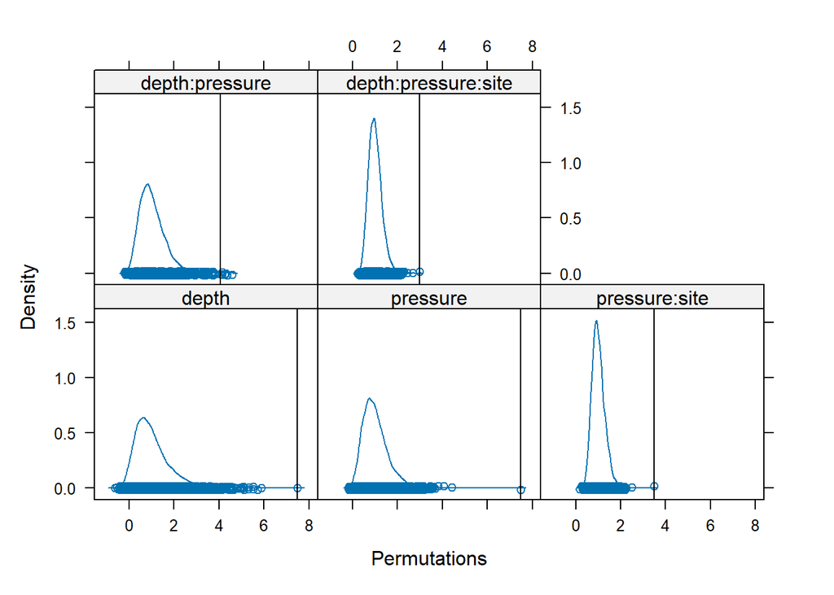

```r
set.seed(69)
densityplot(permustats(inv_permanova)) #density plot of permutation results to to check if assumptions are met?
```

```r
inv_dist = vegdist(inv_mat,
                   method="bray")
```

PERMDISP PER PRESSURE

```r
inv_bd_pressure = betadisper(inv_dist, ind_df$pressure)  #Implements Marti Anderson's PERMDISP2 procedure for the analysis of multivariate homogeneity of group dispersions (variances). betadisper is a multivariate analogue of Levene's test for homogeneity of variances
str(inv_bd_pressure)
```

```
## List of 7
##  $ eig            : Named num [1:68] 1.997 1.621 0.828 0.637 0.586 ...
##   ..- attr(*, "names")= chr [1:68] "PCoA1" "PCoA2" "PCoA3" "PCoA4" ...
##  $ vectors        : num [1:69, 1:68] -0.092779 -0.319736 -0.000788 -0.127711 -0.185621 ...
##   ..- attr(*, "dimnames")=List of 2
##   .. ..$ : chr [1:69] "AW_D1" "AW_D2" "AW_D3" "AW_S1" ...
##   .. ..$ : chr [1:68] "PCoA1" "PCoA2" "PCoA3" "PCoA4" ...
##  $ distances      : Named num [1:69] 0.225 0.359 0 0.116 0.277 ...
##   ..- attr(*, "names")= chr [1:69] "AW_D1" "AW_D2" "AW_D3" "AW_S1" ...
##  $ group          : Ord.factor w/ 3 levels "Low"<"Medium"<..: 3 3 3 3 3 3 3 3 3 3 ...
##  $ centroids      : num [1:3, 1:68] -0.0393 0.0127 -0.0265 -0.1024 0.0559 ...
##   ..- attr(*, "dimnames")=List of 2
##   .. ..$ : chr [1:3] "Low" "Medium" "High"
##   .. ..$ : chr [1:68] "PCoA1" "PCoA2" "PCoA3" "PCoA4" ...
##  $ group.distances: num [1:3(1d)] 0.179 0.195 0.295
##   ..- attr(*, "dimnames")=List of 1
##   .. ..$ : chr [1:3] "Low" "Medium" "High"
##  $ call           : language betadisper(d = inv_dist, group = ind_df$pressure)
##  - attr(*, "class")= chr "betadisper"
##  - attr(*, "method")= chr "bray"
##  - attr(*, "type")= chr "median"
##  - attr(*, "bias.adjust")= logi FALSE
```

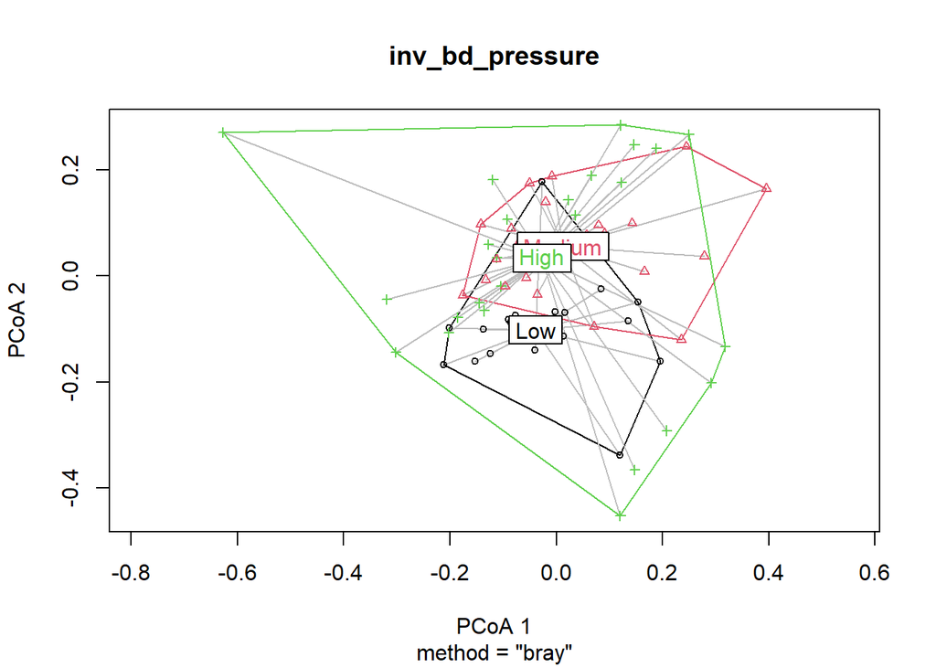

```r
plot(inv_bd_pressure)
```

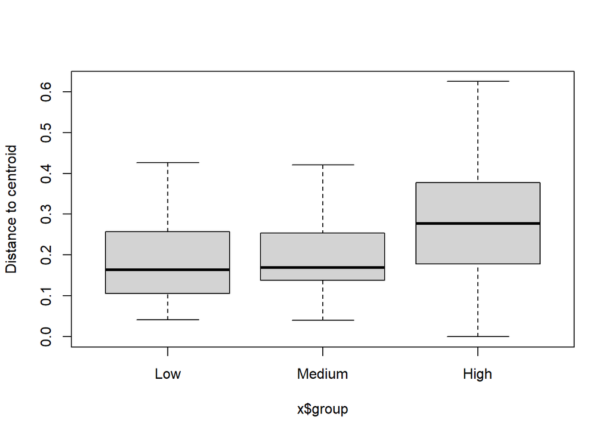

```r
boxplot(inv_bd_pressure) #check data dispersion based on pressures
```

```r
anova(inv_bd_pressure) #F-test on distribution of pressures
```

```
## Analysis of Variance Table
##
## Response: Distances
##           Df  Sum Sq  Mean Sq F value   Pr(>F)
## Groups     2 0.18923 0.094613  6.5393 0.002564 **
## Residuals 66 0.95491 0.014468
## ---
## Signif. codes:  0 '***' 0.001 '**' 0.01 '*' 0.05 '.' 0.1 ' ' 1
```

PERMDISP PER PRESSURE

```r
inv_bd_pressure = betadisper(inv_dist,
                    ind_df$pressure)  #Implements Marti Anderson's PERMDISP2 procedure for the analysis of multivariate homogeneity of group dispersions (variances). betadisper is a multivariate analogue of Levene's test for homogeneity of variances
str(inv_bd_pressure)
```

```
## List of 7
##  $ eig            : Named num [1:68] 1.997 1.621 0.828 0.637 0.586 ...
##   ..- attr(*, "names")= chr [1:68] "PCoA1" "PCoA2" "PCoA3" "PCoA4" ...
##  $ vectors        : num [1:69, 1:68] -0.092779 -0.319736 -0.000788 -0.127711 -0.185621 ...
##   ..- attr(*, "dimnames")=List of 2
##   .. ..$ : chr [1:69] "AW_D1" "AW_D2" "AW_D3" "AW_S1" ...
##   .. ..$ : chr [1:68] "PCoA1" "PCoA2" "PCoA3" "PCoA4" ...
##  $ distances      : Named num [1:69] 0.225 0.359 0 0.116 0.277 ...
##   ..- attr(*, "names")= chr [1:69] "AW_D1" "AW_D2" "AW_D3" "AW_S1" ...
##  $ group          : Ord.factor w/ 3 levels "Low"<"Medium"<..: 3 3 3 3 3 3 3 3 3 3 ...
##  $ centroids      : num [1:3, 1:68] -0.0393 0.0127 -0.0265 -0.1024 0.0559 ...
##   ..- attr(*, "dimnames")=List of 2
##   .. ..$ : chr [1:3] "Low" "Medium" "High"
##   .. ..$ : chr [1:68] "PCoA1" "PCoA2" "PCoA3" "PCoA4" ...
##  $ group.distances: num [1:3(1d)] 0.179 0.195 0.295
##   ..- attr(*, "dimnames")=List of 1
##   .. ..$ : chr [1:3] "Low" "Medium" "High"
##  $ call           : language betadisper(d = inv_dist, group = ind_df$pressure)
##  - attr(*, "class")= chr "betadisper"
##  - attr(*, "method")= chr "bray"
##  - attr(*, "type")= chr "median"
##  - attr(*, "bias.adjust")= logi FALSE
```

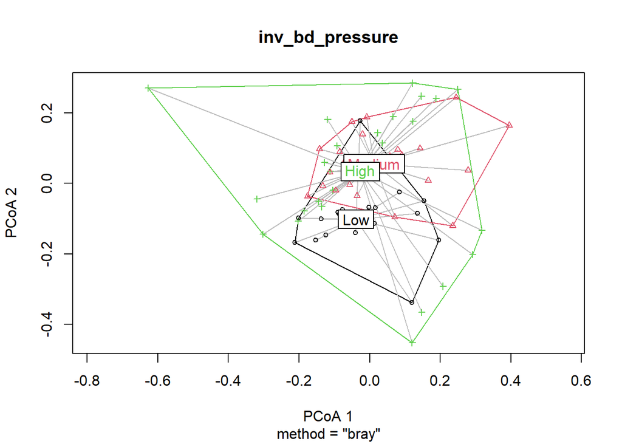

```r
plot(inv_bd_pressure)
```

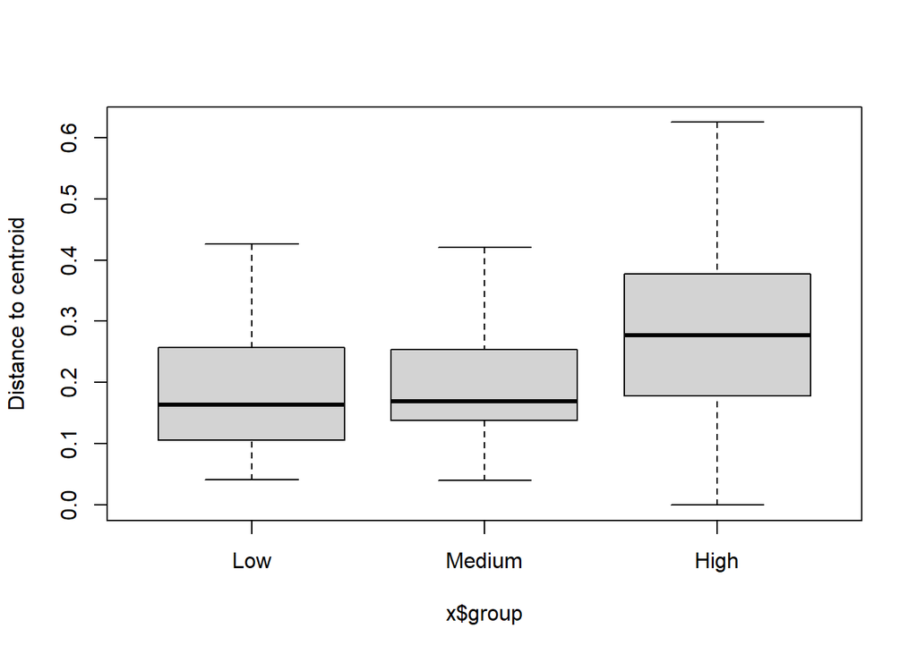

```r
boxplot(inv_bd_pressure) #check data dispersion based on pressures
```

```r
anova(inv_bd_pressure) #F-test on distribution of pressures
```

```
## Analysis of Variance Table
##
## Response: Distances
##           Df  Sum Sq  Mean Sq F value   Pr(>F)
## Groups     2 0.18923 0.094613  6.5393 0.002564 **
## Residuals 66 0.95491 0.014468
## ---
## Signif. codes:  0 '***' 0.001 '**' 0.01 '*' 0.05 '.' 0.1 ' ' 1
```

PERMDISP PER SITE

```r
inv_bd_site = betadisper(inv_dist,
                    ind_df$site)  #Implements Marti Anderson's PERMDISP2 procedure for the analysis of multivariate homogeneity of group dispersions (variances). betadisper is a multivariate analogue of Levene's test for homogeneity of variances
str(inv_bd_site)
```

```
## List of 7
##  $ eig            : Named num [1:68] 1.997 1.621 0.828 0.637 0.586 ...
##   ..- attr(*, "names")= chr [1:68] "PCoA1" "PCoA2" "PCoA3" "PCoA4" ...
##  $ vectors        : num [1:69, 1:68] -0.092779 -0.319736 -0.000788 -0.127711 -0.185621 ...
##   ..- attr(*, "dimnames")=List of 2
##   .. ..$ : chr [1:69] "AW_D1" "AW_D2" "AW_D3" "AW_S1" ...
##   .. ..$ : chr [1:68] "PCoA1" "PCoA2" "PCoA3" "PCoA4" ...
##  $ distances      : Named num [1:69] 0.201 0.2391 0.1831 0.0963 0.1728 ...
##   ..- attr(*, "names")= chr [1:69] "AW_D1" "AW_D2" "AW_D3" "AW_S1" ...
##  $ group          : Ord.factor w/ 12 levels "HI"<"S1"<"S2"<..: 10 10 10 10 10 10 11 11 11 11 ...
##  $ centroids      : num [1:12, 1:68] 0.1159 -0.0675 -0.1085 -0.059 -0.0146 ...
##   ..- attr(*, "dimnames")=List of 2
##   .. ..$ : chr [1:12] "HI" "S1" "S2" "ZP" ...
##   .. ..$ : chr [1:68] "PCoA1" "PCoA2" "PCoA3" "PCoA4" ...
##  $ group.distances: num [1:12(1d)] 0.162 0.107 0.174 0.162 0.185 ...
##   ..- attr(*, "dimnames")=List of 1
##   .. ..$ : chr [1:12] "HI" "S1" "S2" "ZP" ...
##  $ call           : language betadisper(d = inv_dist, group = ind_df$site)
##  - attr(*, "class")= chr "betadisper"
##  - attr(*, "method")= chr "bray"
##  - attr(*, "type")= chr "median"
##  - attr(*, "bias.adjust")= logi FALSE
```

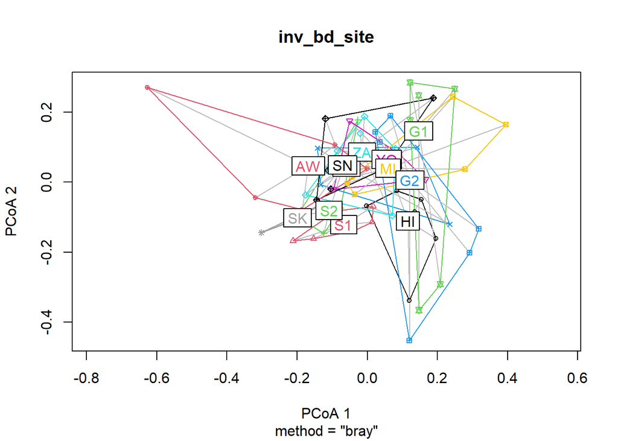

```r
plot(inv_bd_site)
```

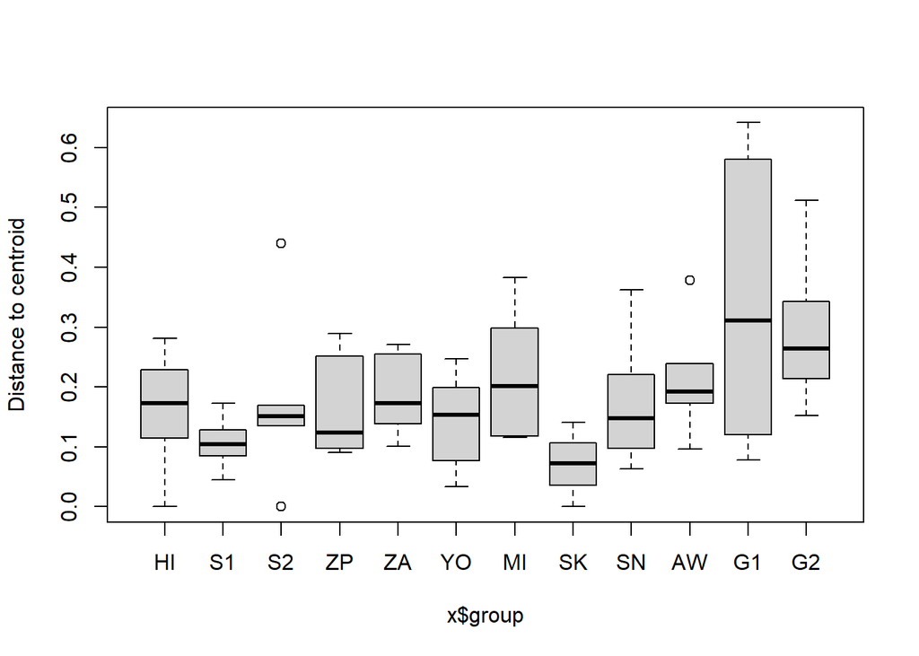

```r
boxplot(inv_bd_site) #check data dispersion based on sites
```

```r
anova(inv_bd_site) #F-test on distribution of sites
```

```
## Analysis of Variance Table
##
## Response: Distances
##           Df  Sum Sq  Mean Sq F value  Pr(>F)
## Groups    11 0.31432 0.028574  1.9617 0.04992 *
## Residuals 57 0.83028 0.014566
## ---
## Signif. codes:  0 '***' 0.001 '**' 0.01 '*' 0.05 '.' 0.1 ' ' 1
```

PERMDISP PER DEPTH

```r
inv_bd_depth = betadisper(inv_dist,
                    ind_df$depth)  #Implements Marti Anderson's PERMDISP2 procedure for the analysis of multivariate homogeneity of group dispersions (variances). betadisper is a multivariate analogue of Levene's test for homogeneity of variances
str(inv_bd_depth)
```

```
## List of 7
##  $ eig            : Named num [1:68] 1.997 1.621 0.828 0.637 0.586 ...
##   ..- attr(*, "names")= chr [1:68] "PCoA1" "PCoA2" "PCoA3" "PCoA4" ...
##  $ vectors        : num [1:69, 1:68] -0.092779 -0.319736 -0.000788 -0.127711 -0.185621 ...
##   ..- attr(*, "dimnames")=List of 2
##   .. ..$ : chr [1:69] "AW_D1" "AW_D2" "AW_D3" "AW_S1" ...
##   .. ..$ : chr [1:68] "PCoA1" "PCoA2" "PCoA3" "PCoA4" ...
##  $ distances      : Named num [1:69] 0.2481 0.3978 0.0515 0.1524 0.2779 ...
##   ..- attr(*, "names")= chr [1:69] "AW_D1" "AW_D2" "AW_D3" "AW_S1" ...
##  $ group          : Factor w/ 2 levels "D","S": 1 1 1 2 2 2 1 1 1 2 ...
##  $ centroids      : num [1:2, 1:68] 0.02914 -0.04667 0.01003 -0.00485 0.03264 ...
##   ..- attr(*, "dimnames")=List of 2
##   .. ..$ : chr [1:2] "D" "S"
##   .. ..$ : chr [1:68] "PCoA1" "PCoA2" "PCoA3" "PCoA4" ...
##  $ group.distances: num [1:2(1d)] 0.273 0.219
##   ..- attr(*, "dimnames")=List of 1
##   .. ..$ : chr [1:2] "D" "S"
##  $ call           : language betadisper(d = inv_dist, group = ind_df$depth)
##  - attr(*, "class")= chr "betadisper"
##  - attr(*, "method")= chr "bray"
##  - attr(*, "type")= chr "median"
##  - attr(*, "bias.adjust")= logi FALSE
```

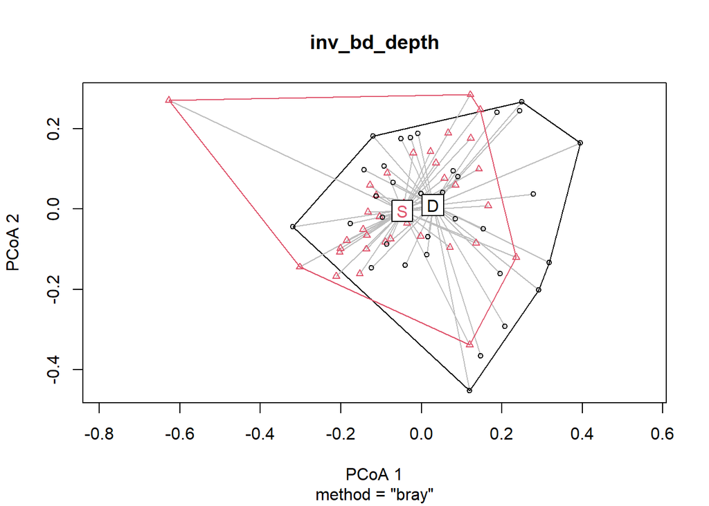

```r
plot(inv_bd_depth)
```

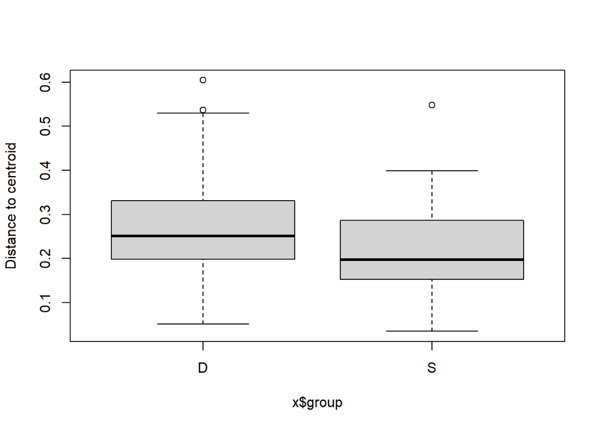

```r
boxplot(inv_bd_depth) #check data dispersion based on depths
```

```r
anova(inv_bd_depth) #F-test on distribution of depths
```

```
## Analysis of Variance Table
##
## Response: Distances
##           Df  Sum Sq  Mean Sq F value  Pr(>F)
## Groups     1 0.05168 0.051680  3.8962 0.05252 .
## Residuals 67 0.88870 0.013264
## ---
## Signif. codes:  0 '***' 0.001 '**' 0.01 '*' 0.05 '.' 0.1 ' ' 1
```

### 8.2.1 Permutest Implements a permutation-based test of multivariate homogeneity of group dispersions (variances)

```r
set.seed(69)
permutest(inv_bd_pressure, pairwise=TRUE) # permutative test on dispersion based on sites, if significant, PERMANOVA results may be driven by  dispersion issue + pairwise of dispersion test
```

```
##
## Permutation test for homogeneity of multivariate dispersions
## Permutation: free
## Number of permutations: 999
##
## Response: Distances
##           Df  Sum Sq  Mean Sq      F N.Perm Pr(>F)
## Groups     2 0.18923 0.094613 6.5393    999  0.002 **
## Residuals 66 0.95491 0.014468
## ---
## Signif. codes:  0 '***' 0.001 '**' 0.01 '*' 0.05 '.' 0.1 ' ' 1
##
## Pairwise comparisons:
## (Observed p-value below diagonal, permuted p-value above diagonal)
##              Low    Medium  High
## Low              0.5570000 0.005
## Medium 0.5796543           0.007
## High   0.0068181 0.0076282
```

### 8.2.2 Permutest Implements a permutation-based test of multivariate homogeneity of group dispersions (variances)

```r
set.seed(69)
permutest(inv_bd_site, pairwise=TRUE, by= "margin") # permutative test on dispersion based on sites, if significant, PERMANOVA results may be driven by  dispersion issue + pairwise of dispersion test
```

```
##
## Permutation test for homogeneity of multivariate dispersions
## Permutation: free
## Number of permutations: 999
##
## Response: Distances
##           Df  Sum Sq  Mean Sq      F N.Perm Pr(>F)
## Groups    11 0.31432 0.028574 1.9617    999  0.049 *
## Residuals 57 0.83028 0.014566
## ---
## Signif. codes:  0 '***' 0.001 '**' 0.01 '*' 0.05 '.' 0.1 ' ' 1
##
## Pairwise comparisons:
## (Observed p-value below diagonal, permuted p-value above diagonal)
##           HI        S1        S2        ZP        ZA        YO        MI
## HI           0.2630000 0.8590000 0.9920000 0.6550000 0.7540000 0.3490000
## S1 0.2512388           0.3280000 0.2130000 0.0290000 0.3530000 0.0290000
## S2 0.8659390 0.2953212           0.8660000 0.8930000 0.6770000 0.5710000
## ZP 0.9940607 0.1874955 0.8635806           0.6420000 0.7380000 0.3820000
## ZA 0.6519466 0.0366929 0.8715867 0.6199377           0.3900000 0.5400000
## YO 0.7448458 0.3327261 0.6623599 0.7128256 0.3575394           0.2110000
## MI 0.3681096 0.0405116 0.5541143 0.3377558 0.5260835 0.2019885
## SK 0.2161818 0.3697138 0.2892967 0.1599410 0.0498226 0.2214045 0.0736628
## SN 0.8544784 0.1936303 0.9895139 0.8491422 0.8268225 0.6076518 0.4809936
## AW 0.3992435 0.0320263 0.6047419 0.3637356 0.5832474 0.2078701 0.8992324
## G1 0.1414934 0.0504178 0.1939902 0.1349638 0.1784399 0.1010422 0.3100599
## G2 0.0779190 0.0065221 0.1633106 0.0638378 0.0963255 0.0351163 0.3138337
##           SK        SN        AW        G1    G2
## HI 0.2230000 0.8510000 0.4210000 0.1350000 0.073
## S1 0.4040000 0.1800000 0.0250000 0.0410000 0.006
## S2 0.3120000 0.9880000 0.6070000 0.1940000 0.168
## ZP 0.1560000 0.8710000 0.3980000 0.1460000 0.063
## ZA 0.0340000 0.8300000 0.5760000 0.1720000 0.084
## YO 0.2160000 0.6030000 0.2160000 0.1060000 0.034
## MI 0.0550000 0.4630000 0.9080000 0.3200000 0.348
## SK           0.1970000 0.0560000 0.1240000 0.023
## SN 0.1899247           0.5520000 0.1640000 0.106
## AW 0.0582886 0.5274875           0.3010000 0.232
## G1 0.1239742 0.1698145 0.2725855           0.694
## G2 0.0274342 0.1118969 0.2413822 0.6826004
```

### 8.2.3 Permutest Implements a permutation-based test of multivariate homogeneity of group dispersions (variances)

```r
set.seed(69)
permutest(inv_bd_depth, pairwise=TRUE) # permutative test on dispersion based on sites, if significant, PERMANOVA results may be driven by  dispersion issue + pairwise of dispersion test
```

```
##
## Permutation test for homogeneity of multivariate dispersions
## Permutation: free
## Number of permutations: 999
##
## Response: Distances
##           Df  Sum Sq  Mean Sq      F N.Perm Pr(>F)
## Groups     1 0.05168 0.051680 3.8962    999  0.055 .
## Residuals 67 0.88870 0.013264
## ---
## Signif. codes:  0 '***' 0.001 '**' 0.01 '*' 0.05 '.' 0.1 ' ' 1
##
## Pairwise comparisons:
## (Observed p-value below diagonal, permuted p-value above diagonal)
##         D     S
## D         0.048
## S 0.05252
```

From Anderson, Marti, Ray N. Gorley, and Robert K. Clarke. Permanova+ for primer: Guide to software and statistical methods. Primer-E Limited, 2008: * If significant heterogeneity were detected by PERMDISP and differences among groups were also detected using PERMANOVA, then the latter could have been caused by differences in location, differences in dispersion, or some combination of the two. *

### 8.2.4 Boxplot of within-site distance from centroid visualization with `ggplot()`

```r
inv_bd_site$distances #Extract betadisper scores
```

```
##      AW_D1      AW_D2      AW_D3      AW_S1      AW_S2      AW_S3      G1_D1
## 0.20101472 0.23908440 0.18311080 0.09629945 0.17278516 0.37860172 0.64173814
##      G1_D2      G1_D3      G1_S1      G1_S2      G1_S3      G2_D1      G2_D2
## 0.47505256 0.57995559 0.07765547 0.11984581 0.14619422 0.34308573 0.26555634
##      G2_D3      G2_S1      G2_S2      G2_S3      HI_D1      HI_D2      HI_D3
## 0.51201648 0.26241096 0.21332967 0.15230252 0.11480403 0.28143740 0.22286898
##      HI_S1      HI_S2      HI_S3      MI_D1      MI_D2      MI_D3      MI_S1
## 0.12275853 0.00000000 0.22888731 0.38289481 0.29865914 0.25125766 0.11532729
##      MI_S2      MI_S3      S1_D1      S1_D2      S1_D3      S1_S1      S1_S2
## 0.15107651 0.11762177 0.04476811 0.12840610 0.09750557 0.11085666 0.17295378
##      S1_S3      S2_D1      S2_D2      S2_D3      S2_S1      S2_S2      S2_S3
## 0.08479904 0.43960735 0.15989889 0.13529752 0.16939952 0.00000000 0.14150930
##      SK_S1      SK_S2      SK_S3      SN_D1      SN_D2      SN_D3      SN_S1
## 0.14079456 0.00000000 0.07237941 0.22067395 0.36259698 0.11351531 0.06330751
##      SN_S2      SN_S3      YO_D1      YO_D2      YO_D3      YO_S1      YO_S2
## 0.09774424 0.18191268 0.17457039 0.19949821 0.24718720 0.03322327 0.13294483
##      YO_S3      ZA_D1      ZA_D2      ZA_D3      ZA_S1      ZA_S2      ZA_S3
## 0.07711252 0.13897646 0.15599232 0.27127564 0.18843815 0.10022279 0.25533077
##      ZP_D1      ZP_D2      ZP_D3      ZP_S1      ZP_S2      ZP_S3
## 0.08989881 0.10602804 0.09691300 0.14015859 0.25106922 0.28919132
```

```r
distcent_df <- data.frame(Distance_to_centroid=inv_bd_site$distances,Sites=ind_df$site, Pressure=ind_df$pressure)
Sites <- inv_bd_site$group
distcent_df[,2]<-factor(distcent_df[,2],levels=c("HI", "S1", "S2", "ZP", "ZA", "YO", "MI","SK", "SN", "AW", "G1", "G2"))
distcent_df[,3]<-factor(distcent_df[,3],levels=c("Low","Medium","High"))

distcent_mean_df <- distcent_df %>%
  group_by(Sites) %>%
  summarise(`Mean distance to centroid`=round(mean(Distance_to_centroid),2),
         SD=round(mean(Distance_to_centroid),2)) %>%
  mutate(Pressure = case_when(Sites == 'HI' |
                              Sites == "S1" |
                              Sites == "S2" |
                              Sites == "ZP"~ "Low",
                              Sites == 'ZA' |
                              Sites == "YO" |
                              Sites == "MI" ~ "Medium",
                              Sites == 'SK' |
                              Sites == 'SN' |
                              Sites == "AW" |
                              Sites == "G1" |
                              Sites == "G2"~ "High"))

distcent_mean_df <- distcent_mean_df[,c(1,4,2,3)]
```

Boxplot with `geom_boxplot` from `ggplot2`

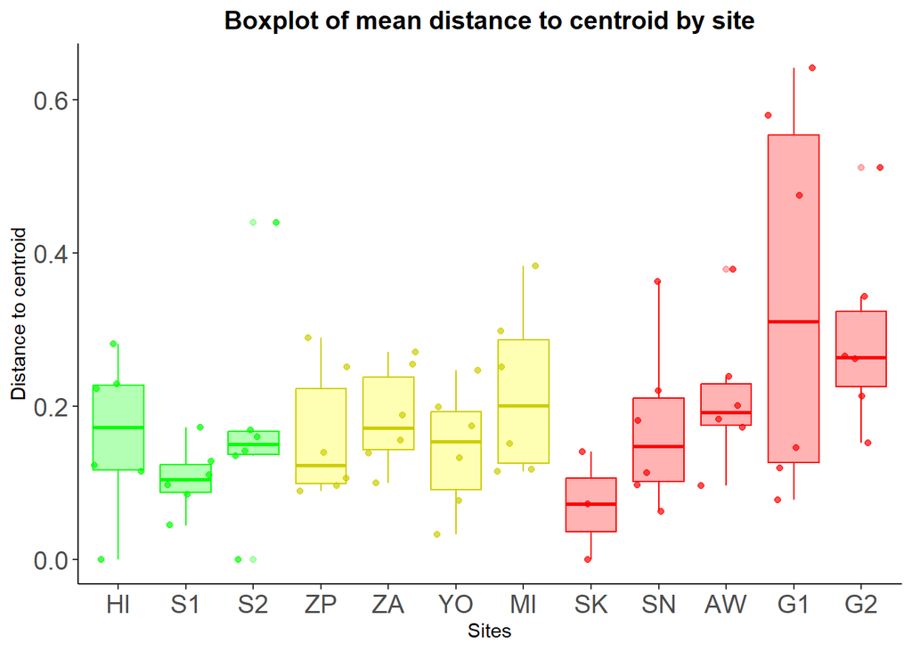

```r
inv_box <- ggplot(data=distcent_df,aes(x=Sites,y=Distance_to_centroid))+
  geom_boxplot(aes(fill=Pressure,colour=Pressure),alpha=0.3)+
  geom_jitter(aes(fill=Pressure,color=Pressure),alpha=0.7)+
  scale_fill_manual(values= c("green","yellow","red"))+
  scale_color_manual(values= c("green","yellow3","red"))+
  theme_classic()+
  labs(title="Boxplot of mean distance to centroid by site")+
  ylab(label="Distance to centroid")+
  theme(legend.position = "none", #remove legend
        plot.title  = element_text(hjust = 0.5, face= "bold", size =14),
        axis.text=element_text(size=14))

inv_box
```

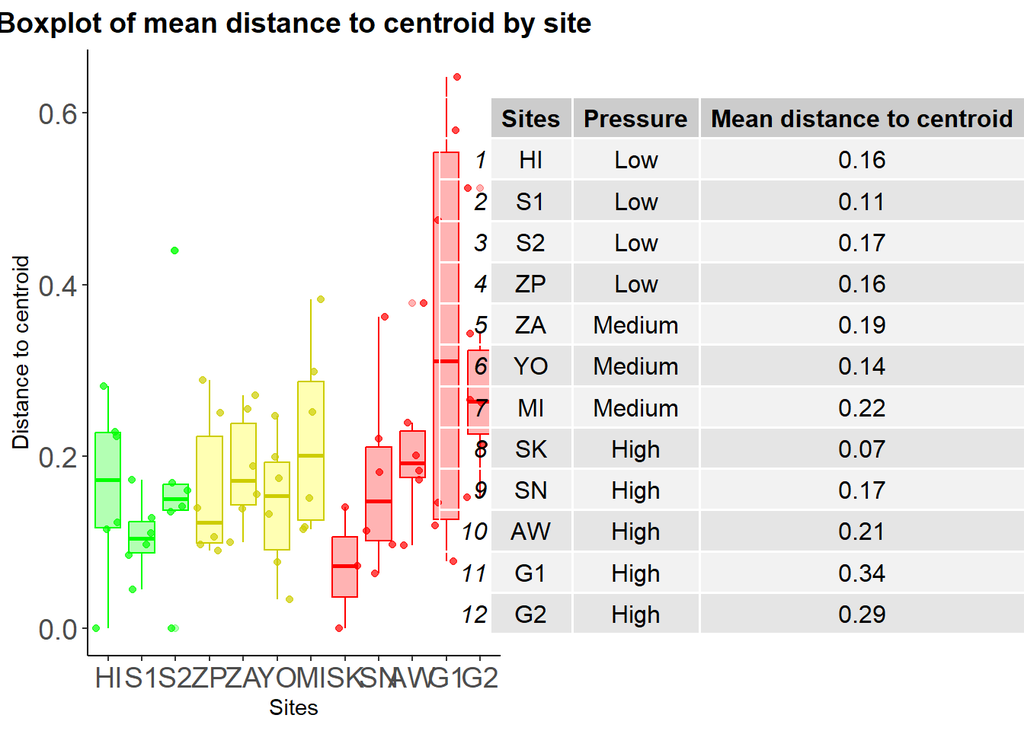

```r
ggpubr:: ggarrange(inv_box,
                   gridExtra::tableGrob(distcent_mean_df),
                   ncol = 2, widths = c(1,1))
```

```r
ggsave("inv_distcent_boxplot.tiff",
       units="in", width=12, height=4, dpi=300, compression = 'lzw',
       path = here ("Multi-taxa_data","MollEchino","Output"))
```

## 8.3 Post hoc test for PERMANOVA (`pairwise.adonis`)

### 8.3.1 Post-hoc test FOR PERMANOVA PER SITES

N.B. `pairwise.adonis` and `pairwise.adonis2` have different syntaxes!

```r
set.seed(69)
inv_pmv_phoc_holm= pairwise.adonis(inv_mat,ind_df$site,
                                  sim.function = "vegdist",
                                  sim.method = "bray",
                                  p.adjust.m = "holm",
                                  reduce = NULL)

inv_pmv_phoc_holm
```

```
##       pairs Df  SumsOfSqs     F.Model          R2 p.value p.adjusted sig
## 1  AW vs G1  1 0.42765522  3.53695703 0.261281544   0.011      0.561
## 2  AW vs G2  2 0.45861309  2.40948392 0.348721257   0.017      0.816
## 3  AW vs HI  2 0.50789611  4.59389842 0.505162716   0.004      0.240
## 4  AW vs MI  1 0.41515963  6.73045857 0.402287752   0.013      0.637
## 5  AW vs S1  1 0.22912023  6.05809819 0.377261250   0.003      0.189
## 6  AW vs S2  2 0.07529846  0.60072504 0.117772480   0.288      1.000
## 7  AW vs SK  1 0.09196796  2.00846557 0.222953127   0.125      1.000
## 8  AW vs SN  1 0.14788810  2.80297705 0.218931662   0.060      1.000
## 9  AW vs YO  1 0.29711782  6.63239452 0.398763661   0.021      0.945
## 10 AW vs ZA  1 0.16509248  3.15540291 0.239856045   0.030      1.000
## 11 AW vs ZP  1 0.34467231  7.16475516 0.417410857   0.005      0.285
## 12 G1 vs G2  1 0.01082454  0.07404651 0.007350225   0.938      1.000
## 13 G1 vs HI  1 0.11965487  1.08495399 0.097876273   0.391      1.000
## 14 G1 vs MI  1 0.04412648  0.36104763 0.034846634   0.831      1.000
```

[output cut: 52 more lines]

```r
set.seed(69)
inv_pmv_phoc_bonf= pairwise.adonis(inv_mat,ind_df$site,
                                  sim.function = "vegdist",
                                  sim.method = "bray",
                                  p.adjust.m = "bonferroni",
                                  reduce = NULL)

inv_pmv_phoc_bonf
```

```
##       pairs Df  SumsOfSqs     F.Model          R2 p.value p.adjusted sig
## 1  AW vs G1  1 0.42765522  3.53695703 0.261281544   0.011      0.726
## 2  AW vs G2  2 0.45861309  2.40948392 0.348721257   0.017      1.000
## 3  AW vs HI  2 0.50789611  4.59389842 0.505162716   0.004      0.264
## 4  AW vs MI  1 0.41515963  6.73045857 0.402287752   0.013      0.858
## 5  AW vs S1  1 0.22912023  6.05809819 0.377261250   0.003      0.198
## 6  AW vs S2  2 0.07529846  0.60072504 0.117772480   0.288      1.000
## 7  AW vs SK  1 0.09196796  2.00846557 0.222953127   0.125      1.000
## 8  AW vs SN  1 0.14788810  2.80297705 0.218931662   0.060      1.000
## 9  AW vs YO  1 0.29711782  6.63239452 0.398763661   0.021      1.000
## 10 AW vs ZA  1 0.16509248  3.15540291 0.239856045   0.030      1.000
## 11 AW vs ZP  1 0.34467231  7.16475516 0.417410857   0.005      0.330
## 12 G1 vs G2  1 0.01082454  0.07404651 0.007350225   0.938      1.000
## 13 G1 vs HI  1 0.11965487  1.08495399 0.097876273   0.391      1.000
## 14 G1 vs MI  1 0.04412648  0.36104763 0.034846634   0.831      1.000
```

[output cut: 52 more lines]

### 8.3.2 Post-hoc test FOR PERMANOVA PER PRESSURE

N.B. `pairwise.adonis` and `pairwise.adonis2` have different syntaxes!

```r
set.seed(69)
inv_pmv_phoc_holm= pairwise.adonis(inv_mat,ind_df$pressure,
                                  sim.function = "vegdist",
                                  sim.method = "bray",
                                  p.adjust.m = "holm",
                                  reduce = NULL)

inv_pmv_phoc_holm
```

```
##            pairs Df SumsOfSqs   F.Model         R2 p.value p.adjusted sig
## 1    High vs Low  1 0.2296804  2.699749 0.05907580   0.034      0.068
## 2 High vs Medium  1 0.2175256  2.652486 0.05135253   0.037      0.068
## 3  Low vs Medium  1 0.4739835 10.469780 0.20744652   0.001      0.003   *
```

```r
set.seed(69)
inv_pmv_phoc_bonf= pairwise.adonis(inv_mat,ind_df$pressure,
                                  sim.function = "vegdist",
                                  sim.method = "bray",
                                  p.adjust.m = "bonferroni",
                                  reduce = NULL)

inv_pmv_phoc_bonf
```

```
##            pairs Df SumsOfSqs   F.Model         R2 p.value p.adjusted sig
## 1    High vs Low  1 0.2296804  2.699749 0.05907580   0.034      0.102
## 2 High vs Medium  1 0.2175256  2.652486 0.05135253   0.037      0.111
## 3  Low vs Medium  1 0.4739835 10.469780 0.20744652   0.001      0.003   *
```

# 9 SIMPER: Similarity of percentage

From the vignette: *The simper functions performs pairwise comparisons of groups of sampling units and finds the contribution of each species to the average between-group Bray-Curtis dissimilarity. Although the method is called simper, it really studied dissimilarities instead of similarities (Clarke 1993).*

## 9.1 SIMPER PER SITE:

```r
inv_sim=simper(inv_mat,
               group=ind_df$site,
               permutations = 9999) #Distinguish categories which caused the differences in relative cover among sites
inv_sim
```

```
## cumulative contributions of most influential species:
##
## $AW_G1
## Echinoidea  Crinoidea Gastropoda
##  0.4206953  0.6538373  0.7620056
##
## $AW_G2
## Echinoidea   Bivalvia  Crinoidea
##  0.4290288  0.5928015  0.7536020
##
## $AW_HI
## Echinoidea Gastropoda   Bivalvia
##  0.3626129  0.5599151  0.7310269
##
## $AW_MI
## Echinoidea  Crinoidea Gastropoda
##  0.3560446  0.5647218  0.7376684
##
## $AW_S1
##   Bivalvia Gastropoda  Crinoidea Echinoidea
##  0.2421535  0.4367942  0.6135065  0.7868604
##
## $AW_S2
##   Bivalvia Gastropoda Echinoidea  Crinoidea
##  0.2402625  0.4418612  0.6331576  0.8212089
##
## $AW_SK
##   Bivalvia  Crinoidea Gastropoda Echinoidea
##  0.3091123  0.4974830  0.6689486  0.8331823
##
## $AW_SN
## Echinoidea Gastropoda   Bivalvia  Crinoidea
##  0.2511196  0.4802341  0.6441445  0.8023038
##
## $AW_YO
## Echinoidea Gastropoda  Crinoidea
##  0.2754610  0.5046857  0.7070320
##
## $AW_ZA
## Echinoidea  Crinoidea Gastropoda   Bivalvia
```

[output cut: 210 more lines]

```
## $SN_ZP
## Echinoidea   Bivalvia Asteroidea Gastropoda
##  0.3533341  0.5187382  0.6614160  0.7840881
##
## $YO_ZA
## Echinoidea Gastropoda  Crinoidea   Bivalvia
##  0.2483762  0.4496558  0.6505666  0.8302049
##
## $YO_ZP
##  Echinoidea  Asteroidea Ophiuroidea   Crinoidea
##   0.3873632   0.5308668   0.6494729   0.7633667
##
## $ZA_ZP
## Echinoidea Gastropoda Asteroidea   Bivalvia
##  0.3278039  0.5139834  0.6530717  0.7811028
```

```r
summary(inv_sim, ordered=T, digits=3) #check which categories were the main driver of difference among sites
```

```
##
## Contrast: AW_G1
##
##               average     sd  ratio    ava    avb cumsum      p
## Echinoidea     0.2349 0.1350 1.7400 4.6900 1.2460   0.42 <2e-16 ***
## Crinoidea      0.1302 0.0834 1.5620 1.5000 2.6270   0.65 <2e-16 ***
## Gastropoda     0.0604 0.0469 1.2870 0.9000 1.4010   0.76   0.34
## Bivalvia       0.0601 0.0481 1.2490 1.0500 0.5970   0.87   0.66
## Holothuroidea  0.0422 0.0427 0.9880 0.5500 0.4510   0.94   0.05 *
## Asteroidea     0.0306 0.0309 0.9900 0.6900 0.3470   1.00   0.79
## Ophiuroidea    0.0000 0.0000    NaN 0.0000 0.0000   1.00     NA
## ---
## Signif. codes:  0 '***' 0.001 '**' 0.01 '*' 0.05 '.' 0.1 ' ' 1
##
## Contrast: AW_G2
##
##               average     sd  ratio    ava    avb cumsum      p
## Echinoidea     0.2136 0.1143 1.8680 4.6900 1.2840   0.43 <2e-16 ***
## Bivalvia       0.0816 0.0651 1.2530 1.0500 1.5740   0.59  0.081 .
## Crinoidea      0.0801 0.0680 1.1780 1.5000 2.1690   0.75  0.207
## Gastropoda     0.0572 0.0430 1.3320 0.9000 1.3450   0.87  0.414
## Holothuroidea  0.0339 0.0293 1.1590 0.5500 0.2310   0.94  0.253
## Asteroidea     0.0315 0.0273 1.1570 0.6900 0.4140   1.00  0.741
## Ophiuroidea    0.0000 0.0000    NaN 0.0000 0.0000   1.00     NA
## ---
## Signif. codes:  0 '***' 0.001 '**' 0.01 '*' 0.05 '.' 0.1 ' ' 1
##
## Contrast: AW_HI
##
##               average     sd  ratio    ava    avb cumsum     p
## Echinoidea     0.1694 0.0826 2.0500 4.6900 1.6220   0.36 0.004 **
## Gastropoda     0.0921 0.0519 1.7760 0.9000 2.5300   0.56 0.008 **
## Bivalvia       0.0799 0.0549 1.4550 1.0500 2.2860   0.73 0.098 .
## Crinoidea      0.0690 0.0505 1.3650 1.5000 2.0400   0.88 0.434
## Holothuroidea  0.0302 0.0242 1.2470 0.5500 0.7130   0.94 0.402
## Asteroidea     0.0264 0.0260 1.0140 0.6900 0.3470   1.00 0.909
## Ophiuroidea    0.0000 0.0000    NaN 0.0000 0.0000   1.00    NA
## ---
## Signif. codes:  0 '***' 0.001 '**' 0.01 '*' 0.05 '.' 0.1 ' ' 1
##
```

[output cut: 769 more lines]

```
##
## Contrast: ZA_ZP
##
##               average     sd  ratio    ava    avb cumsum      p
## Echinoidea     0.0997 0.0549 1.8150 3.4100 3.9100   0.33   0.64
## Gastropoda     0.0566 0.0468 1.2100 1.9500 3.1200   0.51   0.45
## Asteroidea     0.0423 0.0324 1.3050 0.8300 1.6300   0.65   0.22
## Bivalvia       0.0389 0.0276 1.4130 1.3500 1.3700   0.78   0.99
## Crinoidea      0.0341 0.0247 1.3810 2.6500 2.3500   0.89   0.99
## Ophiuroidea    0.0325 0.0366 0.8860 0.0000 0.7800   1.00 <2e-16 ***
## Holothuroidea  0.0000 0.0000    NaN 0.0000 0.0000   1.00     NA
## ---
## Signif. codes:  0 '***' 0.001 '**' 0.01 '*' 0.05 '.' 0.1 ' ' 1
## Permutation: free
## Number of permutations: 9999
```

## 9.2 SIMPER PER DEPTH:

```r
inv_sim_depth = simper(inv_mat,
                     group = ind_df$depth) #Distinguish categories which caused the differences in relative cover among sites
inv_sim_depth
```

```
## cumulative contributions of most influential species:
##
## $D_S
## Echinoidea  Crinoidea   Bivalvia Gastropoda
##  0.3006664  0.4815995  0.6569852  0.8065940
```

```r
summary(inv_sim_depth, ordered=T, digits=3) #check which categories were the main driver of difference among sites
```

```
##
## Contrast: D_S
##
##               average     sd  ratio    ava    avb cumsum     p
## Echinoidea     0.1126 0.0881 1.2790 2.5280 3.6000   0.30 0.011 *
## Crinoidea      0.0678 0.0549 1.2350 2.0510 2.1800   0.48 0.179
## Bivalvia       0.0657 0.0496 1.3250 1.3410 1.7800   0.66 0.147
## Gastropoda     0.0560 0.0485 1.1550 1.8010 2.2600   0.81 0.046 *
## Asteroidea     0.0375 0.0312 1.2020 0.5300 0.9000   0.91 0.059 .
## Holothuroidea  0.0292 0.0301 0.9700 0.5430 0.2300   0.98 0.041 *
## Ophiuroidea    0.0058 0.0206 0.2820 0.0000 0.1300   1.00 0.189
## ---
## Signif. codes:  0 '***' 0.001 '**' 0.01 '*' 0.05 '.' 0.1 ' ' 1
## Permutation: free
## Number of permutations: 999
```

## 9.3 SIMPER per anthropogenic pressure exposure

```r
inv_sim_pres = simper(inv_mat,
                    group=ind_df$pressure,
                    permutations= 9999) #Distinguish categories which caused the differences in relative cover among sites
inv_sim_pres
```

```
## cumulative contributions of most influential species:
##
## $High_Low
## Echinoidea   Bivalvia  Crinoidea Gastropoda
##  0.2767160  0.4838645  0.6619175  0.8129528
##
## $High_Medium
## Echinoidea  Crinoidea Gastropoda   Bivalvia
##  0.3066787  0.4945209  0.6636692  0.8231888
##
## $Low_Medium
## Echinoidea   Bivalvia  Crinoidea Gastropoda
##  0.2415828  0.4292778  0.6143822  0.7435818
```

```r
summary(inv_sim_pres, ordered=T, digits=3) #check which categories were the main driver of difference among sites
```

```
##
## Contrast: High_Low
##
##               average     sd  ratio    ava    avb cumsum      p
## Echinoidea     0.1074 0.0748 1.4350 3.0970 3.0050   0.28   0.50
## Bivalvia       0.0804 0.0562 1.4300 1.3010 2.3700   0.48 <2e-16 ***
## Crinoidea      0.0691 0.0551 1.2540 1.9230 1.6650   0.66   0.37
## Gastropoda     0.0586 0.0489 1.1990 1.5610 2.1790   0.81   0.21
## Holothuroidea  0.0408 0.0291 1.4010 0.3140 0.9000   0.92 <2e-16 ***
## Asteroidea     0.0318 0.0267 1.1900 0.7130 0.3150   1.00   0.97
## Ophiuroidea    0.0000 0.0000    NaN 0.0000 0.0000   1.00     NA
## ---
## Signif. codes:  0 '***' 0.001 '**' 0.01 '*' 0.05 '.' 0.1 ' ' 1
##
## Contrast: High_Medium
##
##               average     sd  ratio    ava    avb cumsum     p
## Echinoidea     0.1160 0.0865 1.3410 3.0970 3.1410   0.31 0.054 .
## Crinoidea      0.0710 0.0562 1.2650 1.9230 2.6760   0.50 0.186
## Gastropoda     0.0640 0.0524 1.2210 1.5610 2.4780   0.66 0.002 **
## Bivalvia       0.0603 0.0446 1.3510 1.3010 1.2710   0.82 0.943
## Asteroidea     0.0396 0.0326 1.2130 0.7130 1.0380   0.93 0.056 .
## Holothuroidea  0.0186 0.0291 0.6380 0.3140 0.0580   0.98 1.000
## Ophiuroidea    0.0087 0.0247 0.3520 0.0000 0.1950   1.00 0.001 ***
## ---
## Signif. codes:  0 '***' 0.001 '**' 0.01 '*' 0.05 '.' 0.1 ' ' 1
##
## Contrast: Low_Medium
##
##               average     sd  ratio    ava    avb cumsum      p
## Echinoidea     0.0830 0.0627 1.3250 3.0050 3.1410   0.24   1.00
## Bivalvia       0.0645 0.0446 1.4480 2.3700 1.2710   0.43   0.54
## Crinoidea      0.0636 0.0460 1.3840 1.6650 2.6760   0.61   0.73
## Gastropoda     0.0444 0.0403 1.1010 2.1790 2.4780   0.74   0.97
## Holothuroidea  0.0403 0.0264 1.5270 0.9000 0.0580   0.86 <2e-16 ***
## Asteroidea     0.0398 0.0303 1.3130 0.3150 1.0380   0.98   0.11
## Ophiuroidea    0.0081 0.0228 0.3540 0.0000 0.1950   1.00   0.24
## ---
## Signif. codes:  0 '***' 0.001 '**' 0.01 '*' 0.05 '.' 0.1 ' ' 1
## Permutation: free
## Number of permutations: 9999
```

# 11 References

```r
#install.packages("report")
library(report)
report(sessionInfo())
```

```
## Analyses were conducted using the R Statistical language (version 4.4.1; R Core
## Team, 2024) on Windows 11 x64 (build 22631), using the packages magrittr
## (version 2.0.3; Bache S, Wickham H, 2022), janitor (version 2.2.0; Firke S,
## 2023), cluster (version 2.1.6; Maechler M et al., 2023), report (version 0.5.9;
## Makowski D et al., 2023), pairwiseAdonis (version 0.4; Martinez Arbizu P,
## 2017), here (version 1.0.1; Müller K, 2020), vegan (version 2.6.6.1; Oksanen J
## et al., 2024), ggforce (version 0.4.2; Pedersen T, 2024), lattice (version
## 0.22.6; Sarkar D, 2008), permute (version 0.9.7; Simpson G, 2022), MASS
## (version 7.3.61; Venables WN, Ripley BD, 2002), reshape2 (version 1.4.4;
## Wickham H, 2007), ggplot2 (version 3.5.1; Wickham H, 2016), readxl (version
## 1.4.3; Wickham H, Bryan J, 2023), usethis (version 2.2.3; Wickham H et al.,
## 2024), dplyr (version 1.1.4; Wickham H et al., 2023), devtools (version 2.4.5;
## Wickham H et al., 2022) and tidyr (version 1.3.1; Wickham H et al., 2024).
##
## References
## ----------
##   - Bache S, Wickham H (2022). _magrittr: A Forward-Pipe Operator for R_. R
## package version 2.0.3, <https://CRAN.R-project.org/package=magrittr>.
##   - Firke S (2023). _janitor: Simple Tools for Examining and Cleaning Dirty
## Data_. R package version 2.2.0, <https://CRAN.R-project.org/package=janitor>.
##   - Maechler M, Rousseeuw P, Struyf A, Hubert M, Hornik K (2023). _cluster:
## Cluster Analysis Basics and Extensions_. R package version 2.1.6 - For new
## features, see the 'NEWS' and the 'Changelog' file in the package source),
## <https://CRAN.R-project.org/package=cluster>.
##   - Makowski D, Lüdecke D, Patil I, Thériault R, Ben-Shachar M, Wiernik B (2023).
## "Automated Results Reporting as a Practical Tool to Improve Reproducibility and
## Methodological Best Practices Adoption." _CRAN_.
## <https://easystats.github.io/report/>.
##   - Martinez Arbizu P (2017). _pairwiseAdonis: Pairwise Multilevel Comparison
## using Adonis_. R package version 0.4, commit
## ece560d2364992e5751bd31431f505805e29f73d,
## <https://github.com/pmartinezarbizu/pairwiseAdonis>.
##   - Müller K (2020). _here: A Simpler Way to Find Your Files_. R package version
## 1.0.1, <https://CRAN.R-project.org/package=here>.
##   - Oksanen J, Simpson G, Blanchet F, Kindt R, Legendre P, Minchin P, O'Hara R,
## Solymos P, Stevens M, Szoecs E, Wagner H, Barbour M, Bedward M, Bolker B,
## Borcard D, Carvalho G, Chirico M, De Caceres M, Durand S, Evangelista H,
## FitzJohn R, Friendly M, Furneaux B, Hannigan G, Hill M, Lahti L, McGlinn D,
## Ouellette M, Ribeiro Cunha E, Smith T, Stier A, Ter Braak C, Weedon J (2024).
## _vegan: Community Ecology Package_. R package version 2.6-6.1,
```

[output cut: 17 more lines]

```
## Springer-Verlag New York. ISBN 978-3-319-24277-4,
## <https://ggplot2.tidyverse.org>.
##   - Wickham H, Bryan J (2023). _readxl: Read Excel Files_. R package version
## 1.4.3, <https://CRAN.R-project.org/package=readxl>.
##   - Wickham H, Bryan J, Barrett M, Teucher A (2024). _usethis: Automate Package
## and Project Setup_. R package version 2.2.3,
## <https://CRAN.R-project.org/package=usethis>.
##   - Wickham H, François R, Henry L, Müller K, Vaughan D (2023). _dplyr: A Grammar
## of Data Manipulation_. R package version 1.1.4,
## <https://CRAN.R-project.org/package=dplyr>.
##   - Wickham H, Hester J, Chang W, Bryan J (2022). _devtools: Tools to Make
## Developing R Packages Easier_. R package version 2.4.5,
## <https://CRAN.R-project.org/package=devtools>.
##   - Wickham H, Vaughan D, Girlich M (2024). _tidyr: Tidy Messy Data_. R package
## version 1.3.1, <https://CRAN.R-project.org/package=tidyr>.
```